# lab1_相关分析

PB20010372 任宣霏

2022-09-26

# 1. 安装程序包（package）

```r
> install.packages(c("corrplot","alr4")) # 安装
```

```r
library(corrplot)
```

# 2. 相关系数

## 2.1 相关系数及其可视化

```r
> cor(state.x77)
```

```
##             Population     Income  Illiteracy    Life Exp     Murder
## Population  1.00000000  0.2082276  0.10762237 -0.06805195  0.3436428
## Income      0.20822756  1.0000000 -0.43707519  0.34025534 -0.2300776
## Illiteracy  0.10762237 -0.4370752  1.00000000 -0.58847793  0.7029752
## Life Exp   -0.06805195  0.3402553 -0.58847793  1.00000000 -0.7808458
## Murder      0.34364275 -0.2300776  0.70297520 -0.78084575  1.0000000
## HS Grad    -0.09848975  0.6199323 -0.65718861  0.58221620 -0.4879710
## Frost      -0.33215245  0.2262822 -0.67194697  0.26206801 -0.5388834
## Area        0.02254384  0.3633154  0.07726113 -0.10733194  0.2283902
##                HS Grad      Frost        Area
## Population -0.09848975 -0.3321525  0.02254384
## Income      0.61993232  0.2262822  0.36331544
## Illiteracy -0.65718861 -0.6719470  0.07726113
## Life Exp    0.58221620  0.2620680 -0.10733194
## Murder     -0.48797102 -0.5388834  0.22839021
## HS Grad     1.00000000  0.3667797  0.33354187
## Frost       0.36677970  1.0000000  0.05922910
## Area        0.33354187  0.0592291  1.00000000
```

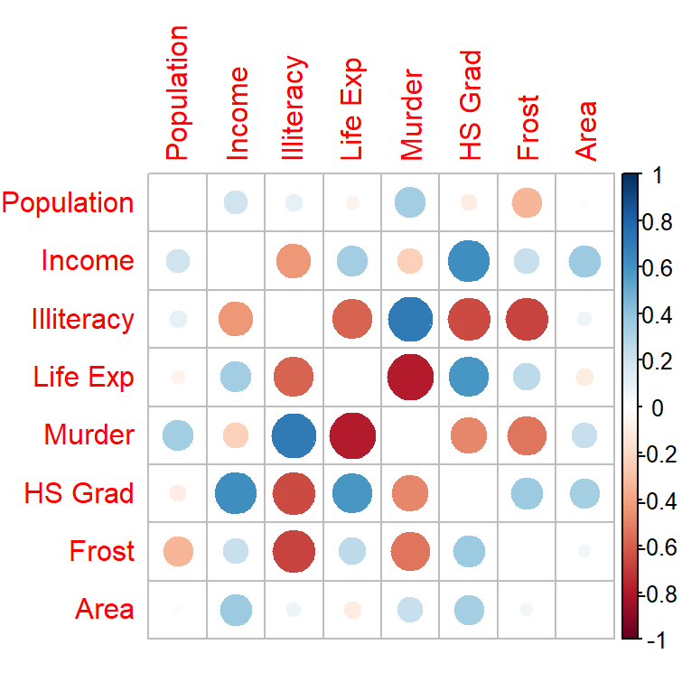

```r
> R=cor(state.x77) # Pearson 相关系数
> corrplot(R,diag=F)# 主对角线上不显示
```

## 2.2 相关性检验

```r
> r=R["Murder","Frost"] # get the cor
> cor.test(state.x77[,"Murder"],state.x77[,"Frost"]) # or
```

```
##
##  Pearson's product-moment correlation
##
## data:  state.x77[, "Murder"] and state.x77[, "Frost"]
## t = -4.4321, df = 48, p-value = 5.405e-05
## alternative hypothesis: true correlation is not equal to 0
## 95 percent confidence interval:
##  -0.7106377 -0.3065115
## sample estimates:
##        cor
## -0.5388834
```

```r
> cor.test(~Murder+Frost,data=state.x77)
```

```
##
##  Pearson's product-moment correlation
##
## data:  Murder and Frost
## t = -4.4321, df = 48, p-value = 5.405e-05
## alternative hypothesis: true correlation is not equal to 0
## 95 percent confidence interval:
##  -0.7106377 -0.3065115
## sample estimates:
##        cor
## -0.5388834
```

手工计算大样本检验

```r
> r=R["Murder","Frost"]
> z=sqrt(50-2)*r
> pvalue=2*(1-pnorm(abs(z)))
> pvalue
```

```
## [1] 0.0001888417
```

## 2.3 置换检验

```r
> x=state.x77[,"Frost"]
> y=state.x77[,"Murder"]
> n=length(x)
> #r0=cor(x,y)
> t0=sum(x*y)-n*mean(x)*mean(y)
> #R_per=NULL
> t_per=NULL
> N=1000000
> for(i in 1:N){
+   x_per=sample(x) # 置换x
+   t_per[i]=sum(x_per*y)-n*mean(x)*mean(y)
+  # R_per[i]=cor(x_per,y)
+ }
> #p1=mean(abs(R_per)>=abs(r0))
> p2=mean(abs(t_per)>=abs(t0))
> print(p2)
```

```
## [1] 6.9e-05
```

### 练习1

随机产生数据，检查t-检验与置换检验的结果（p值）几乎相同

```r
> n=20
> x=rnorm(n)
> y=rnorm(n)
> r0=cor(x,y)
> R_per=NULL
> N=100000
> for(i in 1:N){
+   x_per=sample(x)
+   R_per[i]=cor(x_per,y)
+ }
> pvalue.per=mean(abs(R_per)>=abs(r0))
> cor.test(x,y)->tmp
> pvalue.test=tmp$p.value
> pvalue.test
```

```
## [1] 0.3140216
```

```r
> pvalue.per
```

```
## [1] 0.31705
```

## 2.4 非参数检验

Spearman’s rho 检验

```r
> x=c(2,-2,-11,3,4)
> y=c(0,-1,-3,99,7)
> rankx=rank(x)
> ranky=rank(y)
> person=cor(x,y)
> spearman=cor(rankx,ranky)
> cor.test(x,y,method="spearman")
```

```
##
##  Spearman's rank correlation rho
##
## data:  x and y
## S = 2, p-value = 0.08333
## alternative hypothesis: true rho is not equal to 0
## sample estimates:
## rho
## 0.9
```

### 练习2

上述例子中 Spearman 检验的精确 p 值为 0.08333，它是基于 spearman 系数的原假设下的精确 分布计算得到的，该精确 p 值可用置换检验方法逼近。试分别进行 1000，10000，100000 次置换，按照 公式 (1) 分别计算置换检验 p 值，观察这些 p 值是否接近 0.08333。

```r
> S_per=NULL
> for( N in c(1000,10000,100000) ){
+   for(i in 1:N){
+   x_per=sample(x)
+   S_per[i]=cor(rank(x_per),ranky)
+   }
+   pvalue_per=mean(abs(S_per)>=spearman)
+   print(pvalue_per)
+ }
```

```
## [1] 0.093
## [1] 0.0826
## [1] 0.08315
```

```r
> Omega=solve(R)
> d=diag(Omega)
> D0.5=diag(1/sqrt(d))
> Rpartial=-D0.5%*%Omega%*%D0.5
> diag(Rpartial)=1
> Rpartial
```

```
##             [,1]        [,2]        [,3]         [,4]        [,5]        [,6]
## [1,]  1.00000000  0.32300027 -0.26148742  0.264128233  0.40899056 -0.24492979
## [2,]  0.32300027  1.00000000 -0.09587116 -0.013763485 -0.04286866  0.34074103
## [3,] -0.26148742 -0.09587116  1.00000000  0.014246098  0.24672522 -0.47770796
## [4,]  0.26412823 -0.01376349  0.01424610  1.000000000 -0.70591759  0.30797597
## [5,]  0.40899056 -0.04286866  0.24672522 -0.705917594  1.00000000  0.08682678
## [6,] -0.24492979  0.34074103 -0.47770796  0.307975970  0.08682678  1.00000000
## [7,] -0.22139493  0.01434030 -0.56010767 -0.270999997 -0.25970424 -0.17991875
## [8,] -0.05966557  0.24354899  0.33078309 -0.006829194  0.23544872  0.42343271
##            [,7]         [,8]
## [1,] -0.2213949 -0.059665571
## [2,]  0.0143403  0.243548989
## [3,] -0.5601077  0.330783093
## [4,] -0.2710000 -0.006829194
## [5,] -0.2597042  0.235448722
## [6,] -0.1799187  0.423432714
## [7,]  1.0000000  0.280149525
## [8,]  0.2801495  1.000000000
```

可以将其写成一个函数，输入协方差阵，输出偏相关系数矩阵，如下：

```r
> r2rp=function(R){
+   Omega=solve(R)
+   d=diag(Omega)
+   D0.5=diag(1/sqrt(d))
+   Rp=-D0.5%*%Omega%*%D0.5
+   diag(Rp)=1
+   return(Rp)
+ }
```

## 3.3 高斯图模型

绘出上述数据的高斯图模型：

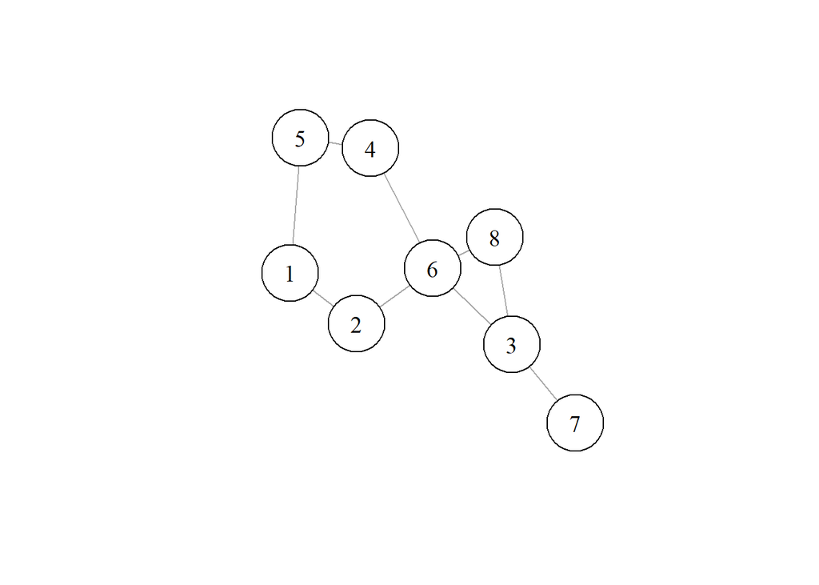

```r
> library(igraph)
> A = abs(Rpartial)> 0.3
> g <- graph.adjacency( A, mode="undirected", diag=FALSE )
> plot.igraph(g, vertex.color="white", vertex.frame.color="black",
+ vertex.label.color="black", vertex.size=40, vertex.label.cex=1.2 )
```

### 练习3

R 数据集 ability.cov 给出了 112 个儿童的 6 项测试成绩的协方差矩阵，6 个科目分别是 general, picture, blocks , maze, reading, vocab （综、绘画、积木、迷宫、阅读、词汇量）。 1. 检验 picture 和 reading 是否相关 (给出 p 值即可)。

```r
> dat=ability.cov$cov # 协方差矩阵
> D=sqrt(diag(1/diag(dat)))
> dat.cor=D%*%dat%*%D # 样本相关系数矩阵
> pvalue1=2*(1-pnorm(abs(sqrt(112)*dat.cor[2,5])))# 大样本检验 sqrt(n)*r 服从N(0,1)
> print(pvalue1)
```

```
## [1] 0.005393952
```

2. 试用 r2rp 函数计算偏相关系数矩阵，使用 corrplot 可视化该矩阵。

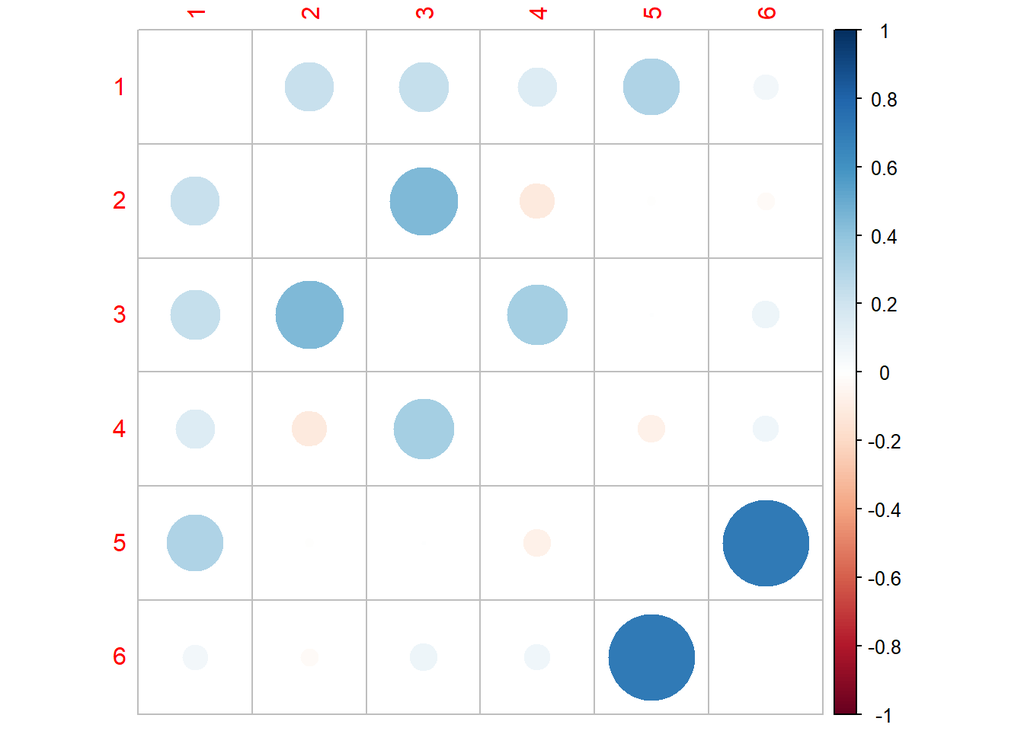

```r
> Omega=r2rp(dat) #求出偏相关系数阵
> corrplot(Omega,diag=F)
```

3. 检验 picture 和 reading 是否偏相关。

```r
> pvalue2=2*(1-pnorm(abs(sqrt(112)*Omega[2,5])))# 大样本检验 sqrt(n)*r 服从N(0,1)
> print(pvalue2)
```

```
## [1] 0.9376338
```

4. （选）将偏相关系数绝对值小于 0.1 的视为 0，画出 6 个科目之间的图表示，解释你的结果是否合理 （画图可用手工，也可用 R 程序包 igraph，用法如下所示）。

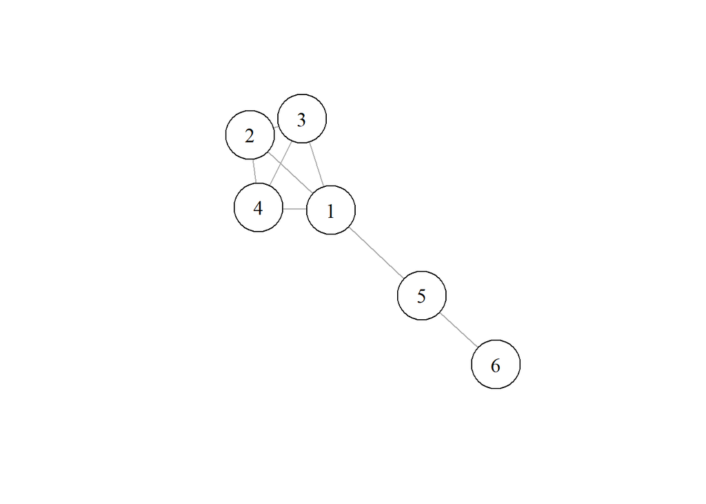

```r
> library(igraph)
> Rp=Omega
> A=abs(Rp)>0.1
> g<-graph.adjacency(A,mode="undirected",diag=F)
> plot.igraph(g,vertex.color="white",vertex.frame.color="black",
+             vertex.label.color="black", vertex.size=40,vertex.label.cex=1.2)
```

# 4. 蒙特卡洛方法

### 例1 估算单位圆面积

```r
> n=100000
> x=runif(n,-1,1);y=runif(n,-1,1)
> m=sum(x^2+y^2<=1)
> p=m/n #落在圆里的比例，即圆和正方形面积比
> S=4*p
> print(S)
```

```
## [1] 3.14532
```

### 例2 $\sqrt{\left|x\right|}$分布

```r
> x=rnorm(n)
> mean(sqrt(abs(x)))
```

```
## [1] 0.8223936
```

```r
> var(sqrt(abs(x)))
```

```
## [1] 0.1219618
```

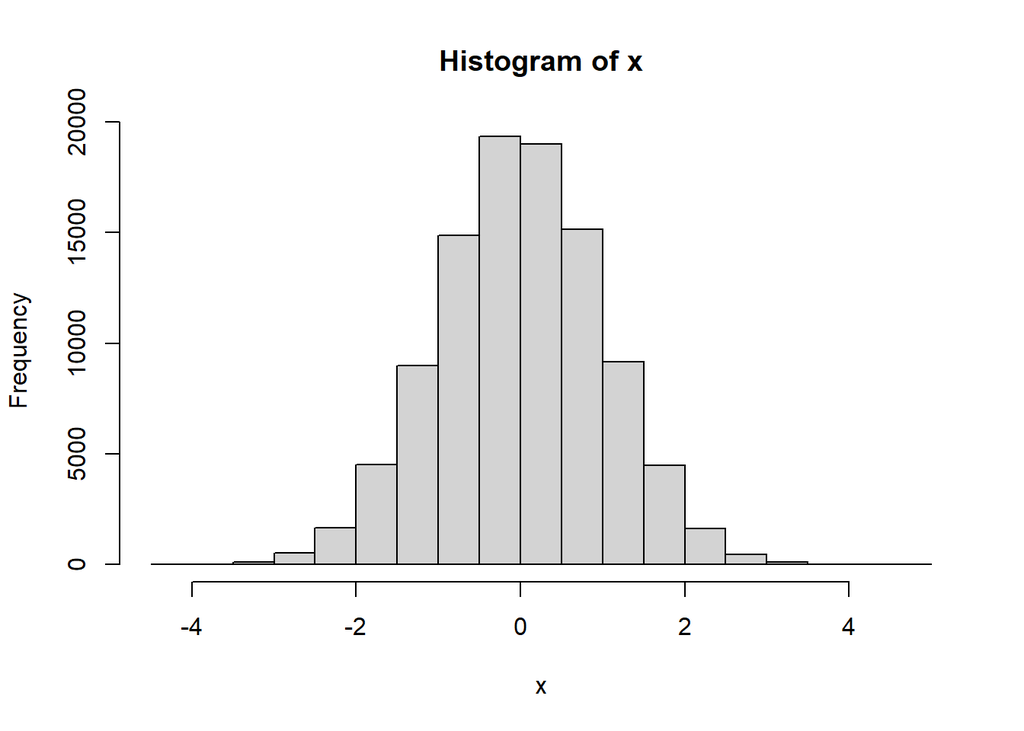

```r
> hist(x)
```

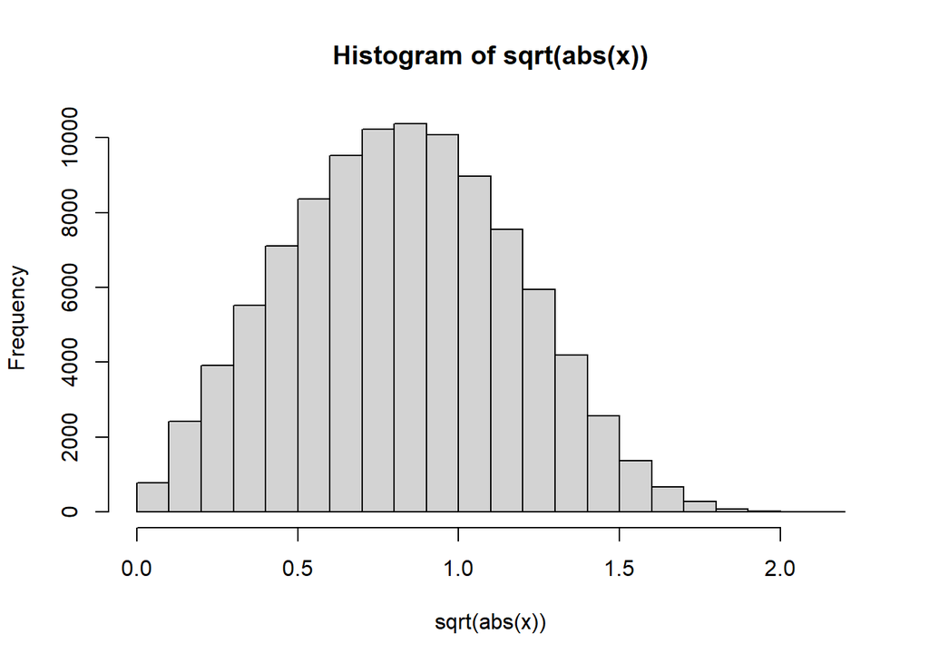

```r
> hist(sqrt(abs(x)))
```

### 例3 相关系数在Fisher z-变换前后的收敛速度比较

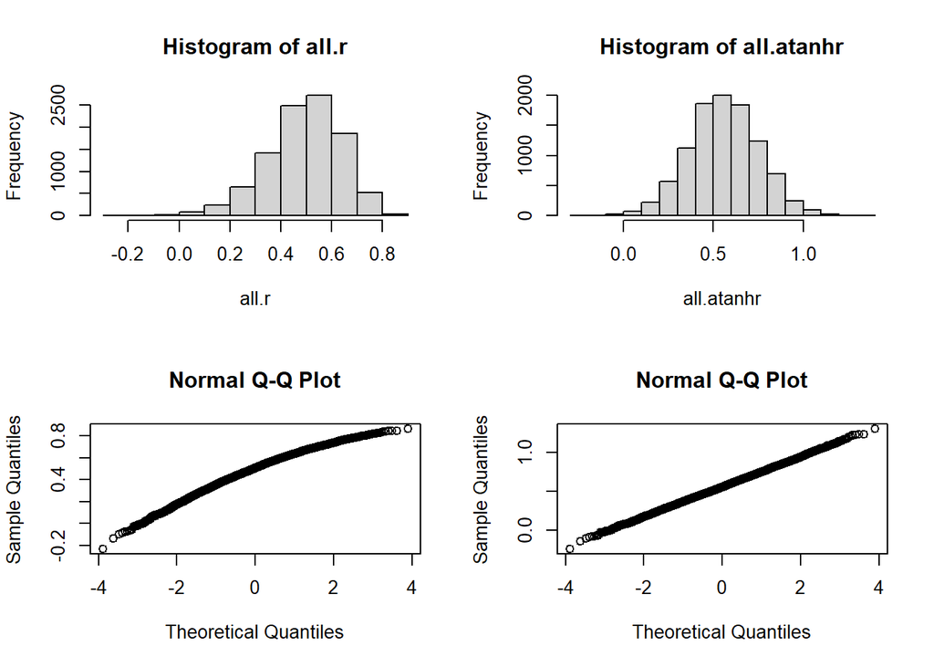

```r
> n=30
> N=10000
> rho=0.5
> all.r=NULL
> all.atanhr=NULL
> for(k in 1:N){
+   u=rnorm(n)
+   v=rnorm(n)
+   x=u
+   y=rho*u+sqrt(1-rho^2)*v
+   r=cor(x,y)
+   all.r=c(all.r,r)
+   tmp=atanh(r)
+   all.atanhr=c(all.atanhr,tmp)
+ }
> par(mfrow=c(2,2))
> hist(all.r)
> hist(all.atanhr)
> qqnorm(all.r)
> qqnorm(all.atanhr)
```

```r
> v=var(all.r)
> print(v)
```

```
## [1] 0.02027274
```

```r
> (1-rho^2)^2/n
```

```
## [1] 0.01875
```

```r
> var(all.atanhr)
```

```
## [1] 0.03687699
```

```r
> 1/n
```

```
## [1] 0.03333333
```

### 练习4

画散点图看渐进分布的方差关系

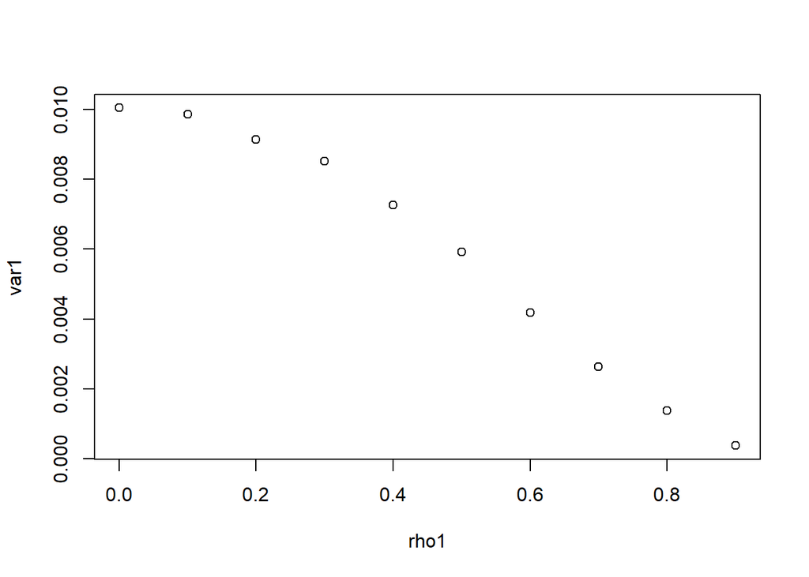

```r
> n=100
> N=10000
> var1=NULL
> rho1=NULL
> for(rho in 0:9){
+   i=rho+1
+   rho=rho/10
+   all.r=NULL
+   for(k in 1:N){
+     u=rnorm(n)
+     v=rnorm(n)
+     x=u
+     y=rho*u+sqrt(1-rho^2)*v
+     r=cor(x,y)
+     all.r=c(all.r,r)
+   }
+   var1=c(var1,var(all.r))
+   rho1=c(rho1,rho)
+ }
> plot(rho1,var1)
```

这时难以看出函数关系。 线性化以后可以看出关系：$v(\rho)=(1-\rho^2)^2/n$.

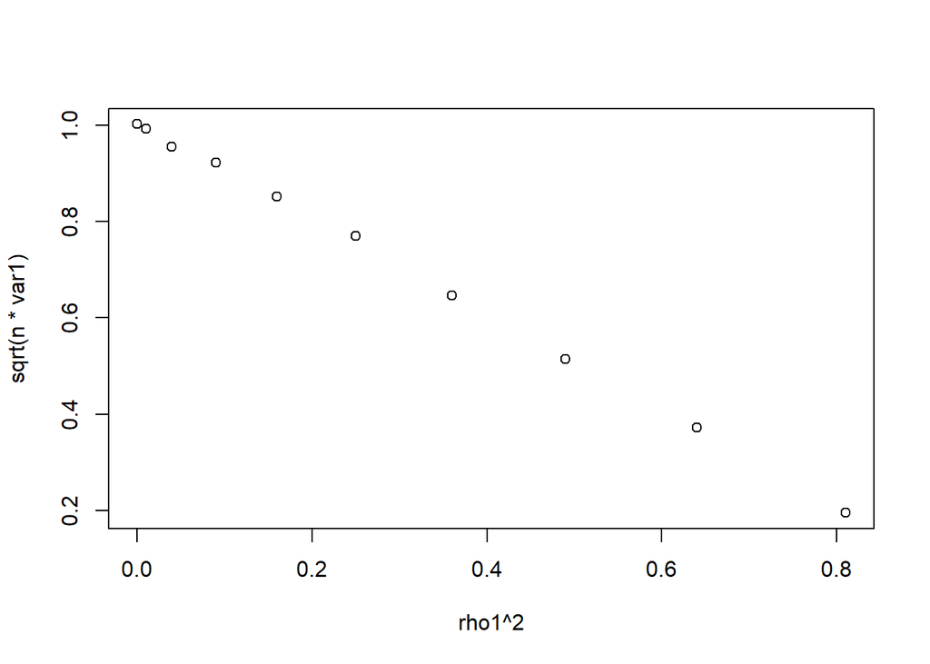

```r
> plot(rho1^2,sqrt(n*var1))
```